# Project

Charlotte Braswell

2023-11-13

# About Rmarkdown

Rmarkdown allows `notebook` formatting similar to Jupyter Notebook in Python. It allows a combination of text and code cells. For VSCode, it required Pandoc (https://github.com/jgm/pandoc/releases/tag/3.1.9) & several R packages. For code cells, the code is provided in the top cell and the output is provided in the next cell. As an example:

```r
a<-1
a
```

```
## [1] 1
```

# Stolen Firearms & Violent Crime

This will look at stolen firearms versus violent crime.

## Import Libraries

```r
library(boot)
library(ggplot2)
```

## Read in Data/Preview Data

```r
df <- read.csv('../data/processed/final_data.csv')
# all rows, certain columns
df <- df[, c('state', 'year', 'month', 'stolen_firearms', 'perc_firearm_involv')]
head(df, n=2)
```

```
##     state year month stolen_firearms perc_firearm_involv
## 1 alabama 2010     1               4                0.25
## 2 alabama 2010     2               3                0.20
```

## Scatterplot

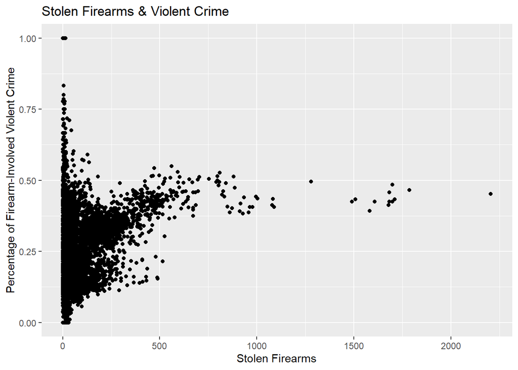

```r
# Create a scatterplot
scatterplot <- ggplot(data = df, aes(x = stolen_firearms, y = perc_firearm_involv)) +
  geom_point() +
  labs(title = "Stolen Firearms & Violent Crime",
       x = "Stolen Firearms",
       y = "Percentage of Firearm-Involved Violent Crime")
print(scatterplot)
```

## Create a Histogram of Stolen Firearms

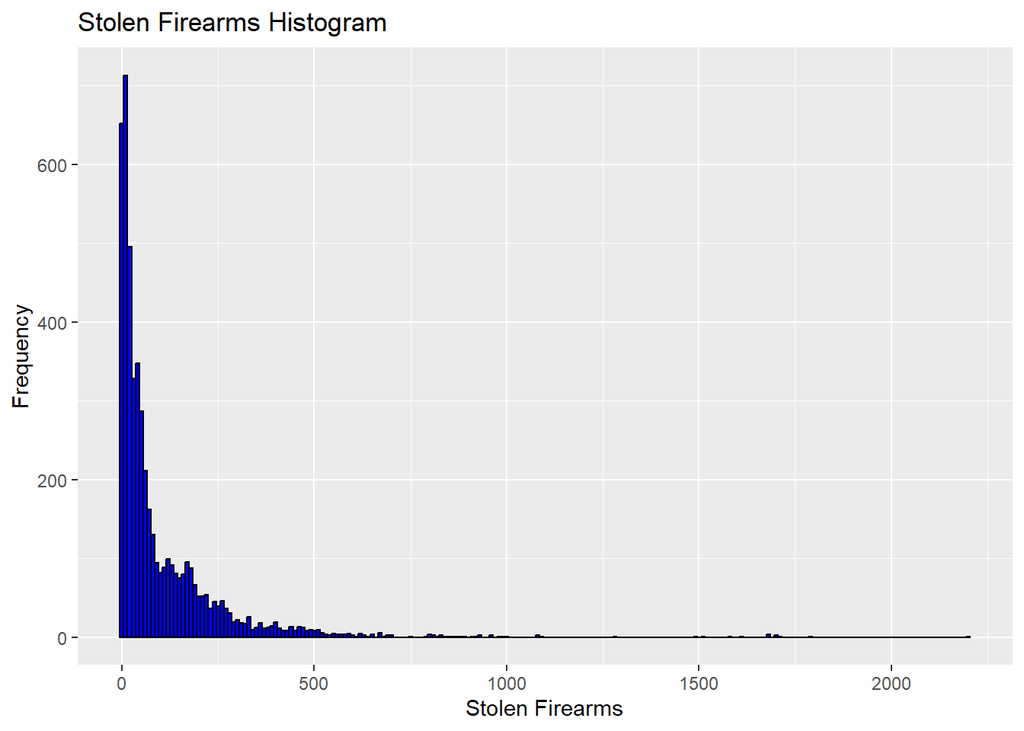

```r
histogram <- ggplot(data = df, aes(x = stolen_firearms)) +
  geom_histogram(binwidth = 10, fill = "blue", color = "black") +
  labs(title = "Stolen Firearms Histogram",
       x = "Stolen Firearms",
       y = "Frequency")

# Display the histogram
print(histogram)
```

## Create a Histogram of Percent Firearm

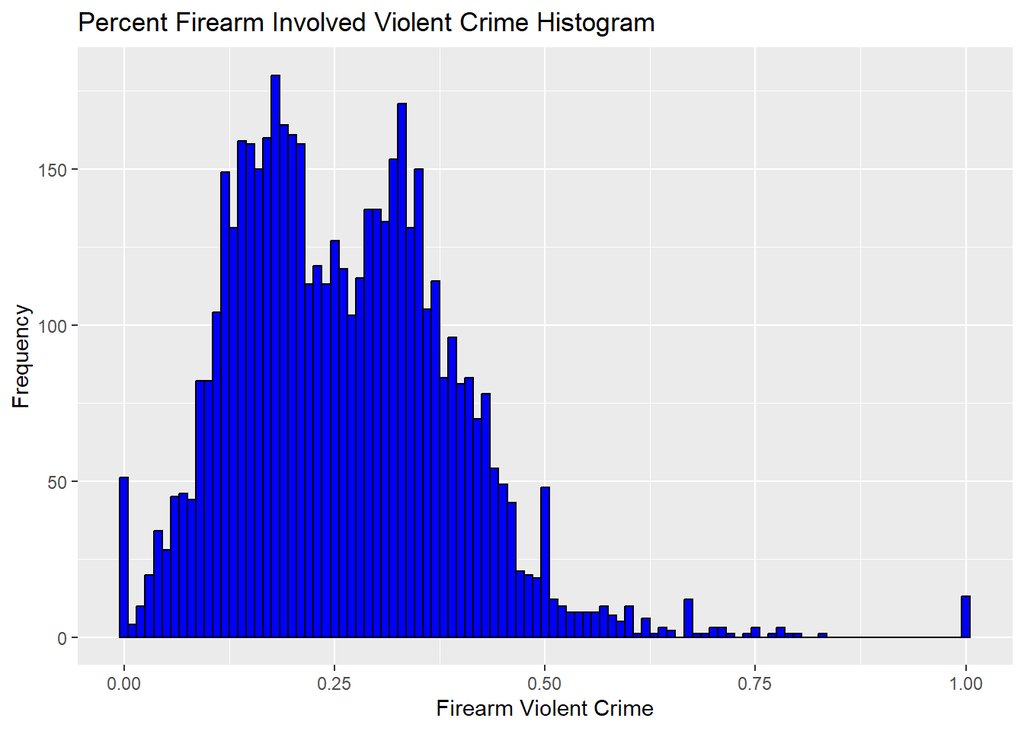

```r
histogram <- ggplot(data = df, aes(x = perc_firearm_involv)) +
  geom_histogram(binwidth = .01, fill = "blue", color = "black") +
  labs(title = "Percent Firearm Involved Violent Crime Histogram",
       x = "Firearm Violent Crime",
       y = "Frequency")

# Display the histogram
print(histogram)
```

## Create a Simple Linear Regression

```r
lm_model <- lm(perc_firearm_involv ~ stolen_firearms, data = df)
summary(lm_model)
```

```
##
## Call:
## lm(formula = perc_firearm_involv ~ stolen_firearms, data = df)
##
## Residuals:
##      Min       1Q   Median       3Q      Max
## -0.33708 -0.09021 -0.00630  0.06552  0.76425
##
## Coefficients:
##                  Estimate Std. Error t value Pr(>|t|)
## (Intercept)     2.355e-01  2.105e-03  111.88   <2e-16 ***
## stolen_firearms 2.508e-04  1.152e-05   21.77   <2e-16 ***
## ---
## Signif. codes:  0 '***' 0.001 '**' 0.01 '*' 0.05 '.' 0.1 ' ' 1
##
## Residual standard error: 0.1249 on 5046 degrees of freedom
## Multiple R-squared:  0.08582,    Adjusted R-squared:  0.08564
## F-statistic: 473.7 on 1 and 5046 DF,  p-value: < 2.2e-16
```

## Create a bootstrapped Simple linear Regression

```r
boot_lm <- function(data, indices) {
  sampled_data <- data[indices, ]
  lm_model <- lm(perc_firearm_involv ~ stolen_firearms, data = sampled_data)
  return(coef(lm_model))
}

set.seed(42)
boot_results <- boot(data = df, statistic = boot_lm, R = 10000)

# Extract the bootstrap results
ts <- boot.ci(boot_results, index=2) # index 1 intercept, index 2 is slope
print(ts)
```

```
## BOOTSTRAP CONFIDENCE INTERVAL CALCULATIONS
## Based on 10000 bootstrap replicates
##
## CALL :
## boot.ci(boot.out = boot_results, index = 2)
##
## Intervals :
## Level      Normal              Basic
## 95%   ( 0.0002,  0.0003 )   ( 0.0002,  0.0003 )
##
## Level     Percentile            BCa
## 95%   ( 0.0002,  0.0003 )   ( 0.0002,  0.0003 )
## Calculations and Intervals on Original Scale
```

## Are they wrong?

It could also be the case that (1) stolen firearms are able to be tracked to recovery, and (2) when tracked to recovery, it’s the recovery of a violent crime involving the firearm. If they were to remove this source of firearms, it is possible that the number of available firearms over time would also decrease (i.e., the actual available firearms in the economy is too small). This is purely hypothetical.

# Domestic Violence Incidents in April 2020 (COVID)

This will look at domestic violence incidents in states with and without domestic violence laws in April 2020.